# diffMIN Tutorial

2024-09-13

## Introduction

This tutorial provides an overview of the **diffMIN** R package, which is designed for computing individuals’ gene regulatory networks.

For more detailed information, please refer to our paper, *`Reconstructing Sample-Specific Differential Gene Regulatory Networks Based on Mutual Information`*.

## Install package

To install the **diffMIN** package, use the following command:

```r
# Install the remotes package if you don't have it
install.packages("remotes")

# Install the diffMIN package from GitHub
remotes::install_github("Juan-shu/diffMIN-R", ref = "master")
```

## Loading data

```r
library(diffMIN)
load("./exp.rda")
print(dim(exp))
```

```
## [1] 22134   482
```

```r
exp[1:10,1:10]
```

```
##                 Sham_1_1   Sham_1_2  Sham_1_3 Sham_1_4   Sham_1_5   Sham_1_6
## 0610005C13Rik   0.000000  0.2807510  0.000000  0.00000  0.0000000  0.0000000
## 0610007C21Rik  39.859549 59.0016117 28.484287 26.26038 64.5853801 57.3831225
## 0610007L01Rik   1.358496  0.0000000  2.217463  3.03680  2.3738523  1.8470840
## 0610007P08Rik   8.066161  0.8338927  0.000000  0.00000  0.1208131  0.2073624
## 0610007P14Rik   0.000000  8.7722382  0.000000  0.00000  0.0000000 13.0441906
## 0610007P22Rik   0.000000  0.0000000  0.000000  0.00000  0.9180985  0.0000000
## 0610008F07Rik   0.000000  0.0000000  0.000000  0.00000  0.0000000  0.0000000
## 0610009B14Rik   0.000000  0.0000000  0.000000  0.00000  0.0000000  0.0000000
## 0610009B22Rik 102.387774 51.9061597 45.720891 81.96516 71.1824403 33.6314899
## 0610009D07Rik  17.941852 20.8872575 26.136393 27.67589 32.3877441 20.5889339
##                Sham_1_7   Sham_1_8  Sham_1_9 Sham_1_10
## 0610005C13Rik   0.00000  0.0000000  0.000000         0
## 0610007C21Rik  85.16572 87.9740394 81.914276         0
## 0610007L01Rik  17.50620 26.8739369  5.708878         0
## 0610007P08Rik   0.00000  0.1865056  3.005625         0
## 0610007P14Rik   0.00000 14.2688661  0.000000         0
## 0610007P22Rik   0.00000  0.0000000  0.000000         0
## 0610008F07Rik   0.00000  0.0000000  0.000000         0
## 0610009B14Rik   0.00000  0.0000000  0.000000         0
## 0610009B22Rik 108.24060 51.0448485 53.317606         0
## 0610009D07Rik  35.98326 36.0258573  0.000000         0
```

## Create a diffMIN_object

The **diffMIN** package includes an S4 `diffMIN_object` specifically designed to store all involved data. This object contains numerous slots, including raw data (`$rawdata`), discretized data (`$data`), degree networks (`$net.DM`), edge networks (`$net.EM`), sample information (`$meta.data`), dimensionality reduction information (`$reduction`), and intermediate networks (`$IN`). All operations performed on a `diffMIN_object` will be saved in the corresponding slots.

**diffMIN** is computationally intensive. Dropout and sparsity in single-cell data can affect analysis.

1. Thus, use the `pre_process()` function for preprocessing. This function filters low-expression samples and probes, and selects a specific number of high-variance genes. Parameters include `exp`, `minExpr_sample`, `minExpr_gene`, and `var.genes`. `minExpr_sample` filters low-expression samples based on minimum detection in genes and sample counts. For instance, `c(0.1,5000)` indicates a sample should have at least `0.1` expression in `5000` genes, while `c(0,20)` indicates a gene should be expressed in at least `20` cells. `var.genes` selects the top `400` genes by variance.
2. The `create_diffMIN_object()` function creates a `diffMIN_object`, initializing many empty slots for data storage. `rawdata` is the pre-processed data with samples as rows and probes as columns. `meta.data` is a data frame for sample information, which can be added at creation or later. Ensure that row names of `meta.data` correspond to sample names.
3. The `discretize_EM()` function, based on the `infotheo` package, discretizes data for subsequent analysis. For details, refer to `?infotheo::discretize`.

```r
exp <- pre_process(exp)
```

```r
obj <- create_diffMIN_object(rawdata = exp)
obj <- discretize_EM(diffMIN_object = obj)
```

## Prepare network

Before computation, specify background samples. Details on background sample specification are available in our paper. Use `addGroup()` to add sample information to the `diffMIN_object`. Here, we use cardiac cells from non-surgical mice as the background.

```r
library(stringr)
group <- colnames(obj@rawdata)[str_detect(colnames(obj@rawdata),"Sham")]
obj <- addGroup(diffMIN_obj = obj,group = group)
```

**diffMIN** uses random permutation testing to validate the network. Use `prepare_network()` to generate random networks. `nRanNet` specifies the number of random networks. For single-cell (sample) networks, random networks will be generated for each cell (sample). Testing shows that `100` random networks are sufficient. The seed parameter ensures result reproducibility.

```r
obj <- prepare_network(diffMIN_object = obj, nRanNet = 100, seed = 1)
```

## Compute network

Use `compute_NMI_network()` for network computation. **diffMIN** is computationally intensive; thus, multi-threading and background execution are recommended. The function includes parameters for multi-threading. `type` specifies whether to compute background or foreground networks.`cores` parameter sets the number of cores. The function will automatically identify the highest number of cores available. `batch_size` sets the number of cells per batch. The function also includes parameters for file saving and `permutation.test.times` for permutation testing, with `p.value.cutoff` indicating the significance level of edges, defaulting to `0.05`. **Note:** Each process will use approximately `22GB` of memory and take about 1 day, so ensure adequate computing resources to prevent server crashes.

```r
obj <- compute_NMI_network(obj,type = "bg",cores = 7,batch_size = 30,filename = "bgnet",
                           p.value.cutoff = 0.05, whether_to_save = F,
                           use_adj.p = F)
obj <- compute_NMI_network(obj,type = "fg",cores = 7,batch_size = 30,filename = "fgnet",
                           p.value.cutoff = 0.05, whether_to_save = F,
                           use_adj.p = F)
```

To reduce computation time, load previously computed data directly:

```r
load("./obj.rda")
```

For further exploration, use `transform_EM_to_DM()` to convert the edge matrix to a degree matrix.

## Reduction

Next, use `RunReduc()` to perform dimensionality reduction on the results, supporting `umap`, `tsne`, and `pca`. The `perplexity` parameter is used for t-SNE calculation. Additional parameters for umap can be passed through `...` to the `umap::umap()` function. The function retains only the first two dimensions. For further dimensionality reduction, extract the degree matrix or edge matrix for analysis.

```r
obj <- RunReduc(obj,reduction = "tsne")
```

## Visualize result

### Unsupervised Clustering

The `cluster()` function performs clustering on dimensionality-reduced data. Users can choose from methods such as `hc` (hierarchical clustering) and `kmean` (k-means clustering) for their analysis. The clustering results will be stored in the `meta.data` slot of the `diffMIN` object.

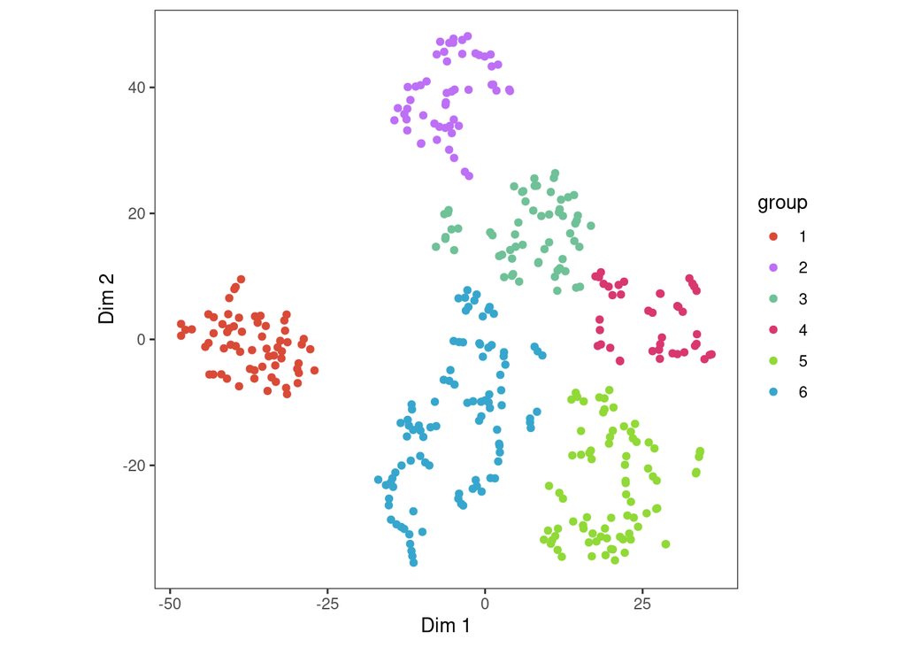

```r
library(ggplot2)
obj <- cluster(obj,centers = 6,reduction.use = "tsne",method = "hc")
plotDot(obj,reduction = "tsne", group.by = "cluster")+coord_fixed(1)
```

### Sample

Use `plotDot()` to visualize the reduction results. Adding group information to meta.data allows for grouping in the plot. Additional plotting parameters can be passed to `ggplot2::ggplot()` using `+`.

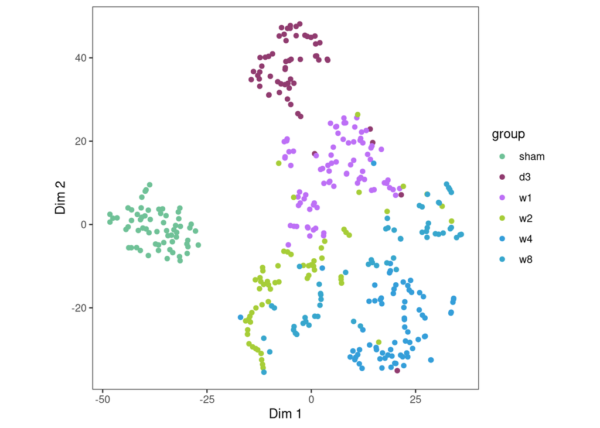

```r
obj@meta.data$time <- factor(rep(c("sham","d3","w1","w2","w4","w8"),
                          c(64,58,82,61,73,58)),
                          levels = c("sham","d3","w1","w2","w4","w8"))
plotDot(obj,reduction = "tsne", group.by = "time")+coord_fixed(1)
```

### Degree

Use `plotdegree()` to visualize the node’s degree. Additional plotting parameters can be passed to `ggplot2::ggplot()` using `+`.

```r
library(gridExtra)
```

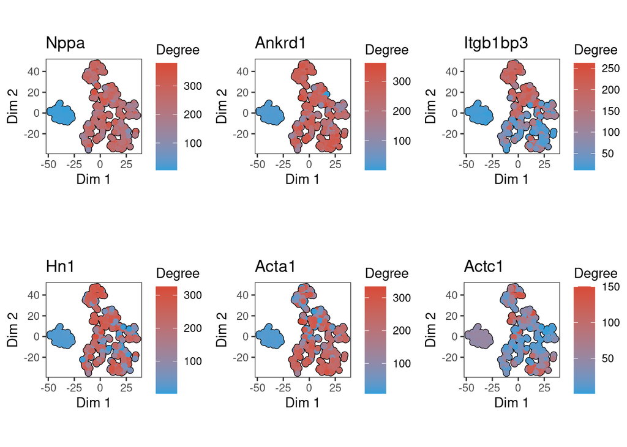

```r
p1 <- plotDegree(obj,"Nppa",reduction = "tsne")+coord_fixed(1)
p2 <- plotDegree(obj,"Ankrd1",reduction = "tsne")+coord_fixed(1)
p3 <- plotDegree(obj,"Itgb1bp3",reduction = "tsne")+coord_fixed(1)
p4 <- plotDegree(obj,"Hn1",reduction = "tsne")+coord_fixed(1)
p5 <- plotDegree(obj,"Acta1",reduction = "tsne")+coord_fixed(1)
p6 <- plotDegree(obj,"Actc1",reduction = "tsne")+coord_fixed(1)
grid.arrange(p1, p2, p3, p4, p5, p6, nrow = 2, ncol = 3)
```

### Edge

When using the `plotHM()` function to plot heatmaps, you can choose between the `edge`, `degree`, and `exp` parameters to visualize the analysis results. Typically, due to the presence of structural proteins, gene expression levels may not fully reflect the importance of genes. Instead, we are more interested in genes with significant changes, even if their expression levels are not very high. Therefore, scaling gene expression data is necessary. However, scaling is not as critical for node degrees, as nodes with higher degrees inherently represent stronger interactions. Thus, in this example, we did not apply scaling to the degree data.

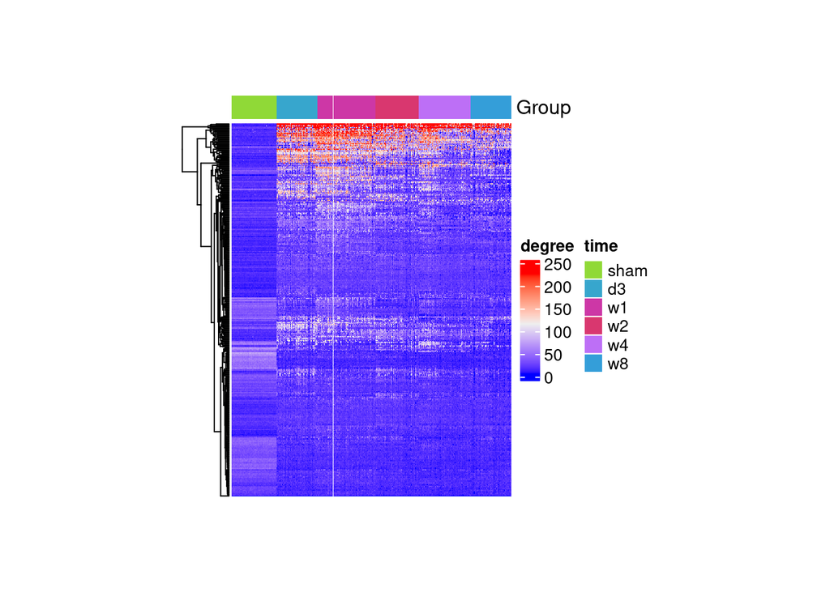

```r
plotHM(obj,scale = F,group.by = "time", type = "degree")
```

```
## The automatically generated colors map from the minus and plus 99^th of
## the absolute values in the matrix. There are outliers in the matrix
## whose patterns might be hidden by this color mapping. You can manually
## set the color to `col` argument.
##
## Use `suppressMessages()` to turn off this message.
```

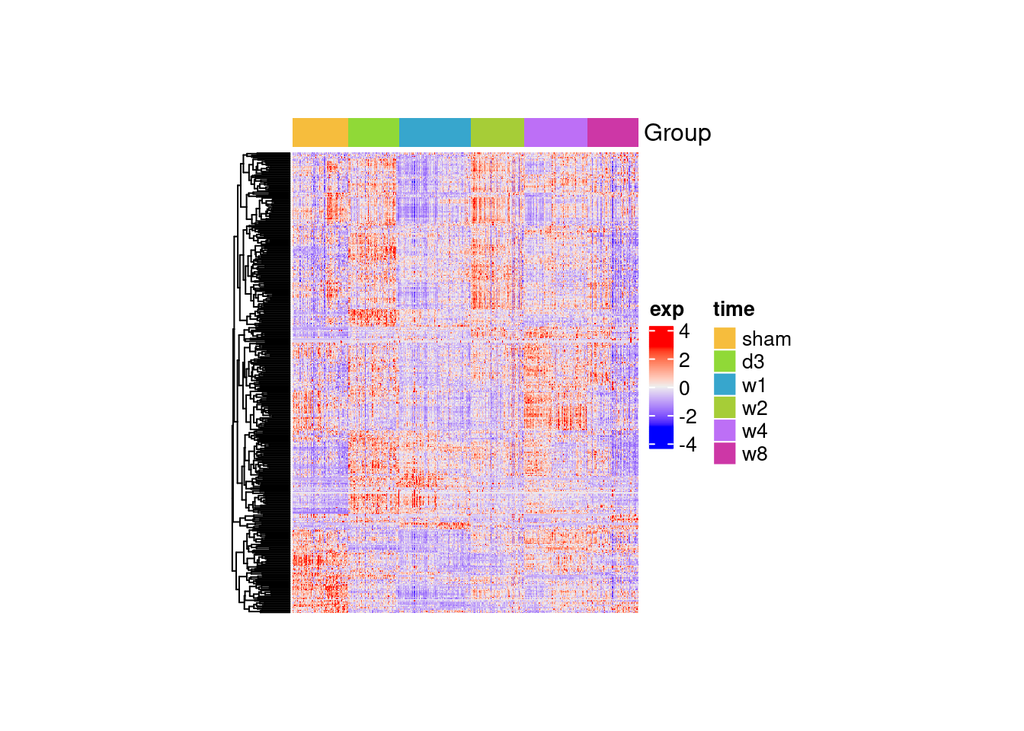

```r
plotHM(obj,scale = T,group.by = "time", type = "exp")
```